# Biostat 276 Homework 1

Zian ZHUANG

## 1. Sampling from the Banana Distribution

### (a)

Describe how to simulate directly from $\pi(x1; x2)$.

**Answer**: Firstly, we can calculate the conditional probability of x2 given X1 and marginal probability of X1.

$$\begin{align}
P(x_2|x_1) &\propto \exp\{-\frac{(x_2-2(x_1^2-5))^2}{2} \} \end{align}$$

note that P(X_2|X_1) is proportional to the normal kernel. Thus we know,

$$\begin{align}
P(x_2|x_1) &= c*\exp\{-\frac{(x_2-2(x_1^2-5))^2}{2} \}\\
&=\frac{1}{\sqrt{2\pi}}\exp\{-\frac{(x_2-2(x_1^2-5))^2}{2} \}\end{align}$$

And we can calculate P(X_1),

$$\begin{align}
P(x_1) &\propto \int\exp\{-\frac{x_1^2}{2} \}\exp\{-\frac{(x_2-2(x_1^2-5))^2}{2} \}dx_2\\
&\propto \exp\{-\frac{x_1^2}{2} \} \int \exp\{-\frac{(x_2-2(x_1^2-5))^2}{2} \}dx_2 \\
&\propto \exp\{-\frac{x_1^2}{2} \}*\sqrt{2\pi}\end{align}$$

note that P(X_1) is proportional to the normal kernel. Thus we know,

$$\begin{align}
P(x_1) &= c*\exp\{-\frac{x_1^2}{2} \}*\sqrt{2\pi}\\
&= \frac{1}{\sqrt{2\pi}}\exp\{-\frac{x_1^2}{2} \}\end{align}$$

Then we can use inverse transformation to generate X_1 and X_2.

Firstly generate uniformly distributed $u_1$, then apply Box-Muller transform to obtain $x_1\sim N/(0,1)$.

Then we can generate uniformly distributed $u_2$, then apply Box-Muller transform to obtain $x_2\sim N/(2(x_1^2-5),1)$.

[code source](https://stackoverflow.com/questions/43618421/generate-n0-1-using-uniform0-1-in-r)

```r
nsim <- 15000
#Box-Muller transform
box_muller <- function(n = 1, mean = 0, sd = 1){
  x <- vector("numeric", n)
  i <- 1
  while(i <= n){
    u1 <- runif(1, 0, 1)
    u2 <- runif(1, 0, 1)
    x[i] <- sqrt(-2 * log(u1)) * cos(2 * pi * u2)
    if ((i + 1) <= n){
      x[i + 1] <- sqrt(-2 * log(u1)) * sin(2 * pi * u2)
      i <- i + 1
    }
    i <- i + 1
  }
  x * sd + mean
}
set.seed(1996)
x_q1 <- box_muller(nsim)
x_q2 <- box_muller(nsim)+2*(x_q1^2-5)
```

### (b)

Describe how to simulate from $\pi(x_1; x_2)$ using the accept-reject method. Implement your algorithm and discuss sampling efficiency in relation to the chosen instrument distribution.

Firstly we can visualize the distribution of $x_1$ and $x_2$

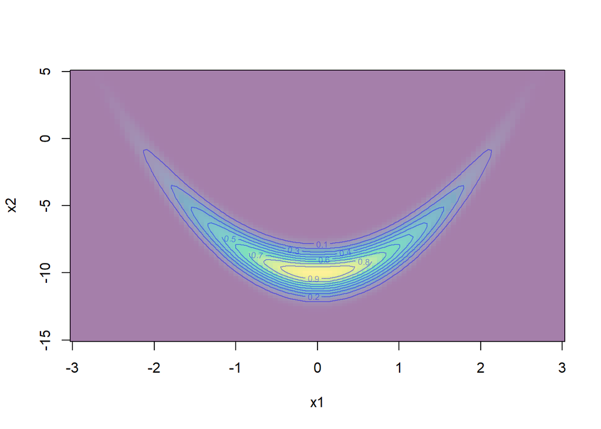

```r
nsim <- 100
x1 <- seq(-3,3,length.out=nsim)
x2 <- seq(-15,5,length.out=nsim)
f <- matrix(0, nsim, nsim)

.banana <- function(x1, x2){
  out <- exp(-x1^2/2)*exp(-(x2-2*(x1^2-5))^2/2)
  return(out)
}

for(i in 1:nsim){
  for(j in 1:nsim){
    temp1 <- x1[i]
    temp2 <- x2[j]
    f[i,j] <- .banana(temp1, temp2)
  }
}


image(x1, x2, f, col=hcl.colors(100, alpha=0.5),
      xlab=expression("x1"),
      ylab=expression("x2"))
contour(x1, x2, f, add=T, col=rgb(0,0,1,alpha=0.4))
```

Since the f is in exp family, it is log-concave and we know that we can always find a majorizing function. According to the previous density plot, we would like to try multivariate t distribution. note that here we use two half of multivariate t distributions that are symmetric with respect to x=0 (y axis), in order to approach the banana distribution more efficiently.

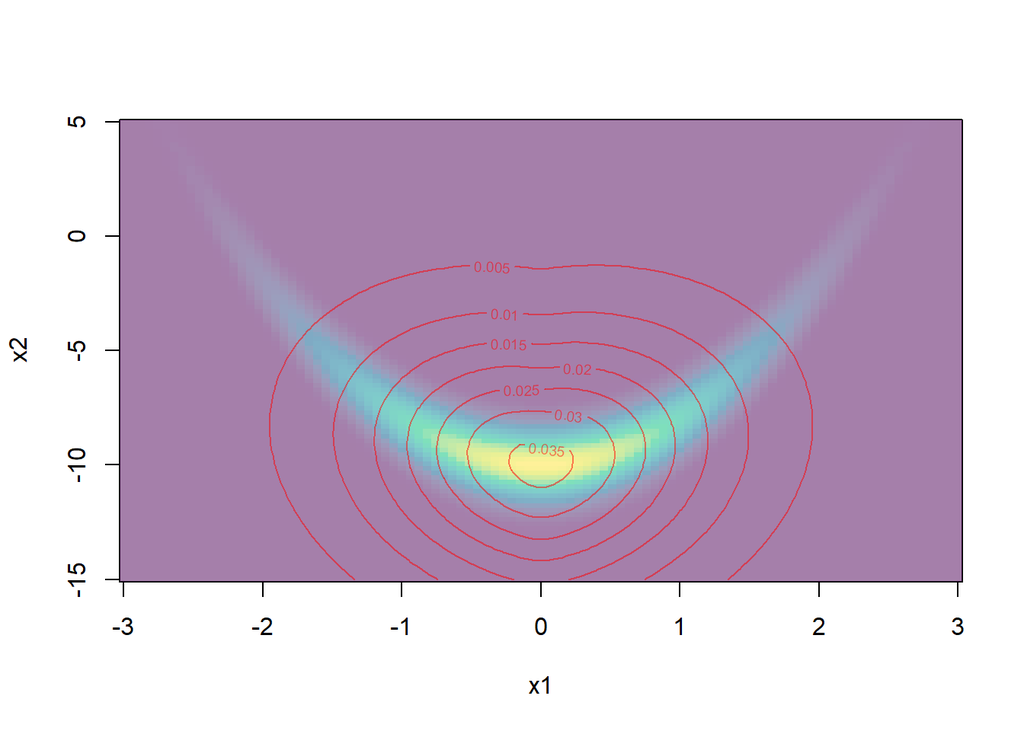

```r
library(mvtnorm)
delta <- c(0, -10)
gb <- matrix(0,nsim,nsim)
Sigma <- matrix(c(1,0.9,0.9,20),2,2)
for(i in 1:100){
  for(j in 1:100){
    betai   = c(abs(x1[i]), x2[j])
    gb[i,j] = dmvt(betai, delta = delta, Sigma, df = 5, log=FALSE)
  }
}

image(x1, x2, f, col=hcl.colors(100, alpha=0.5),
      xlab=expression("x1"),
      ylab=expression("x2"))
contour(x1, x2, gb, add=T, col=rgb(1,0,0,alpha=0.5))
```

AR Sampling function

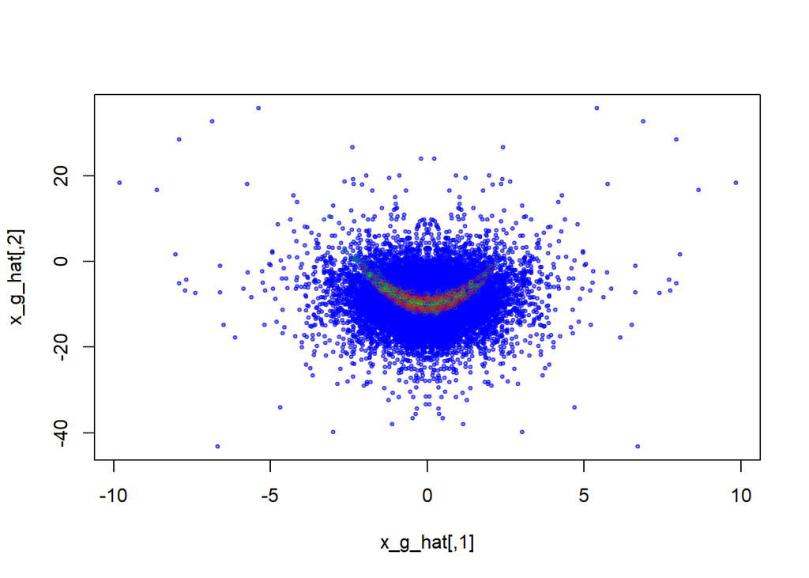

```r
set.seed(1996)
nsim   = 15000
Sigma1 = Sigma
nu     = 5
x_g = rmvt(n = nsim, sigma = Sigma1, df = nu, delta = delta)
#plot(x_g, col=rgb(0,0,1, alpha=0.5), pch=19, cex=0.5)
x_g_hat <- x_g[which(x_g[,1]>=0),]
x_g_hat <- rbind(x_g_hat, x_g_hat)
x_g_hat[(dim(x_g_hat)[1]/2+1):dim(x_g_hat)[1],1] <-
  -abs(x_g_hat[(dim(x_g_hat)[1]/2+1):dim(x_g_hat)[1],1])
nsim <- dim(x_g_hat)[1]

plot(x_g_hat, col=rgb(0,0,1, alpha=0.5), pch=19, cex=0.5)
#
# AR Sampling
#
g = dmvt(x_g_hat, sigma=Sigma1, df=nu, delta=delta, log=FALSE)
#
fx <- rep(NA, nsim)
for(i in 1:nsim){
  temp1 <- x_g_hat[i,1]
  temp2 <- x_g_hat[i,2]
  fx[i] <- .banana(temp1, temp2)
}
f1 = fx
M  = 300
u  = runif(nsim)
#
c1 = f1/g * 1/M
x_AR = x_g_hat[c1 >= u,]
points(x_AR, col=rgb(0,1,0,alpha=0.2), cex=0.5)
contour(x1, x2, f, add=T, col=rgb(1,0,0,alpha=0.4))
```

```r
#efficiency
dim(x_AR)[1]/nsim
```

```
## [1] 0.02580731
```

```r
#model check
which(f1/(g*M)>1) %>% length
```

```
## [1] 0
```

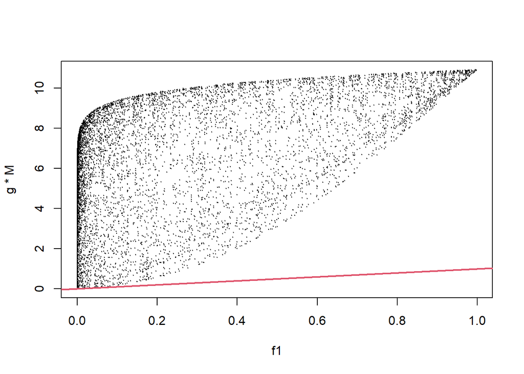

```r
plot(f1, g*M, cex=0.1)
abline(a=0, b=1, col=2, lwd=2)
```

The model has a 2.58% accept rate. And $\frac{fx}{gx*M}\leq1$ is hold.

### (c)

Describe how to simulate from $\pi(x_1; x_2)$ using sampling importance resampling. Implement your algorithm and discuss sampling efficiency in relation to the chosen instrument distribution.

- 1. generate a sample
- 2. calculate importance weights
- 3. normalize calculated weights
- 4. re-sample

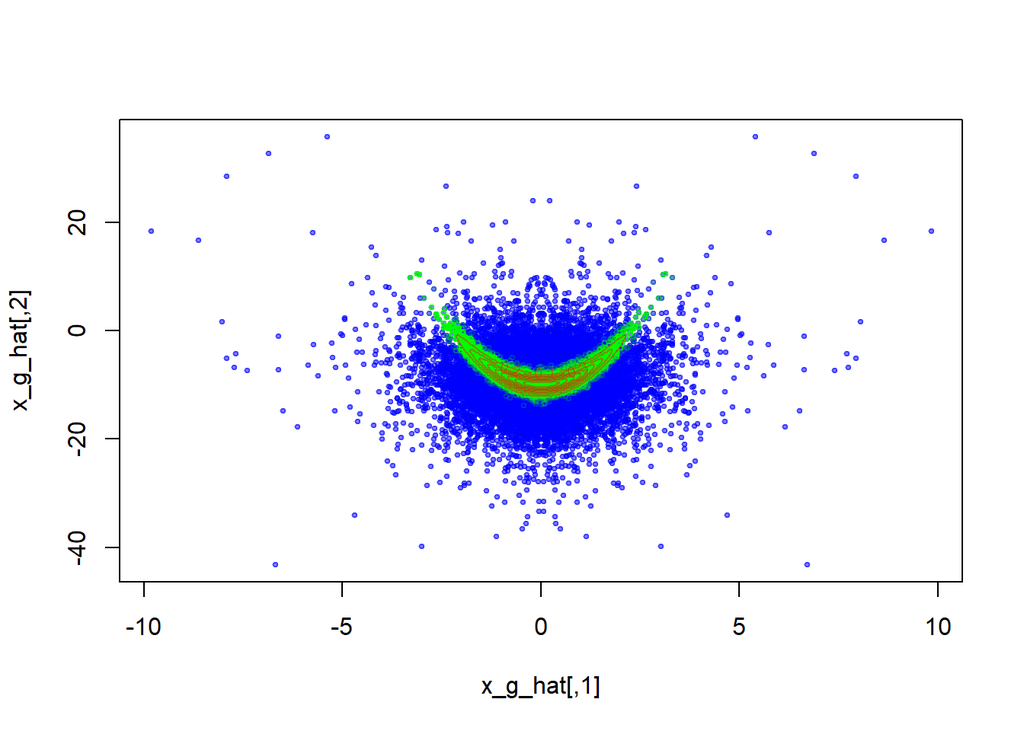

```r
# Using the same simulated values as for the AR algorithm
plot(x_g_hat, col=rgb(0,0,1, alpha=0.5), pch=19, cex=0.5)
# Calculate importance weights
w = f1/g
# normalized weights
w_star = w/sum(w)
samp_ind = seq(1,nsim)
x_ind = sample(samp_ind, prob=w_star, replace=TRUE)
x_IS  = x_g_hat[x_ind,]

points(x_IS,  col=rgb(0,1,0,alpha=0.2), cex=0.5)
contour(x1, x2, f, add=T, col=rgb(1,0,0,alpha=0.4))
```

### (d)

Construct a Markov Chain to sample from $\pi(x1; x2)$ using the Metropolis Hastings algorithm. Compare convergence and mixing for different proposal jump sizes.

Random-walk proposal:

- $x_1^{*}|x_1 \sim N(x_1, \eta)$
- $x_2^{*}|x_2 \sim N(x_2, \delta)$

```r
mh.sim <- function(nsim=1000, burn=0, eta=3, delta=5, seed=1996){
  set.seed(seed)
  x1 <- 0
  x2 <- -10
  nsim.total <- nsim*(1.0 + burn)
  burn.num <- nsim*burn
  x1.ch <- vector()
  x2.ch <- vector()

  for(i in 1:nsim.total){
    x1_temp <- rnorm(1,x1,eta)
    x2_temp <- rnorm(1,x2,delta)
    P0 <- .banana(x1, x2) %>% log
    P1 <- .banana(x1_temp, x2_temp) %>% log
    ratio <- P1 - P0
    if(log(runif(1)) < ratio){
      x1 <- x1_temp
      x2 <- x2_temp
    }
    if(i > burn.num){
      i1 <- i - burn.num
      x1.ch[i1] = x1
      x2.ch[i1] = x2
    }
  }
  return(list(x1=x1.ch, x2=x2.ch))
}
```

simulation begin

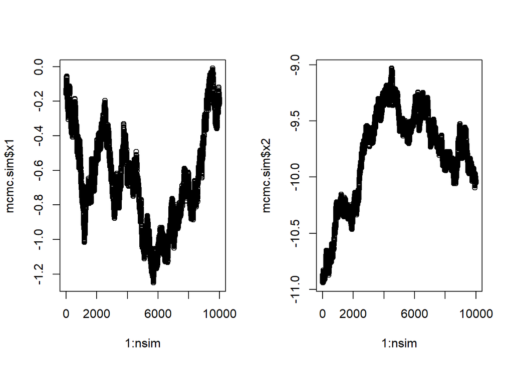

```r
burn=0.3
nsim=10000

# scenario 1
eta <- 0.01
delta <- 0.01
mcmc.sim <- mh.sim(nsim=nsim, eta=eta, delta=delta, burn=burn)
# plot
par(mfrow=c(1,2))
plot(1:nsim, mcmc.sim$x1)
plot(1:nsim, mcmc.sim$x2)
```

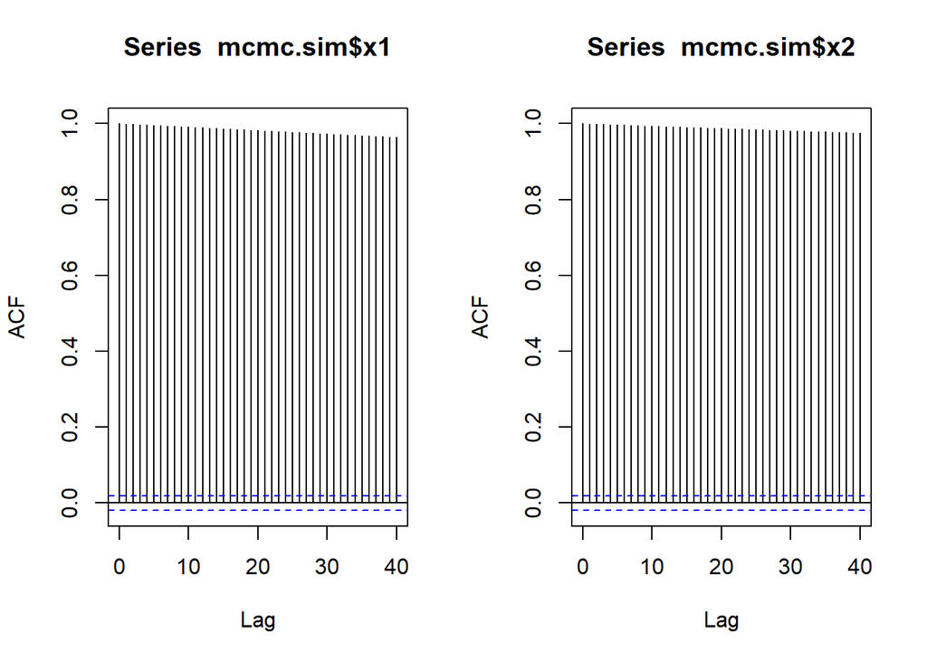

```r
acf(mcmc.sim$x1)
acf(mcmc.sim$x2)
```

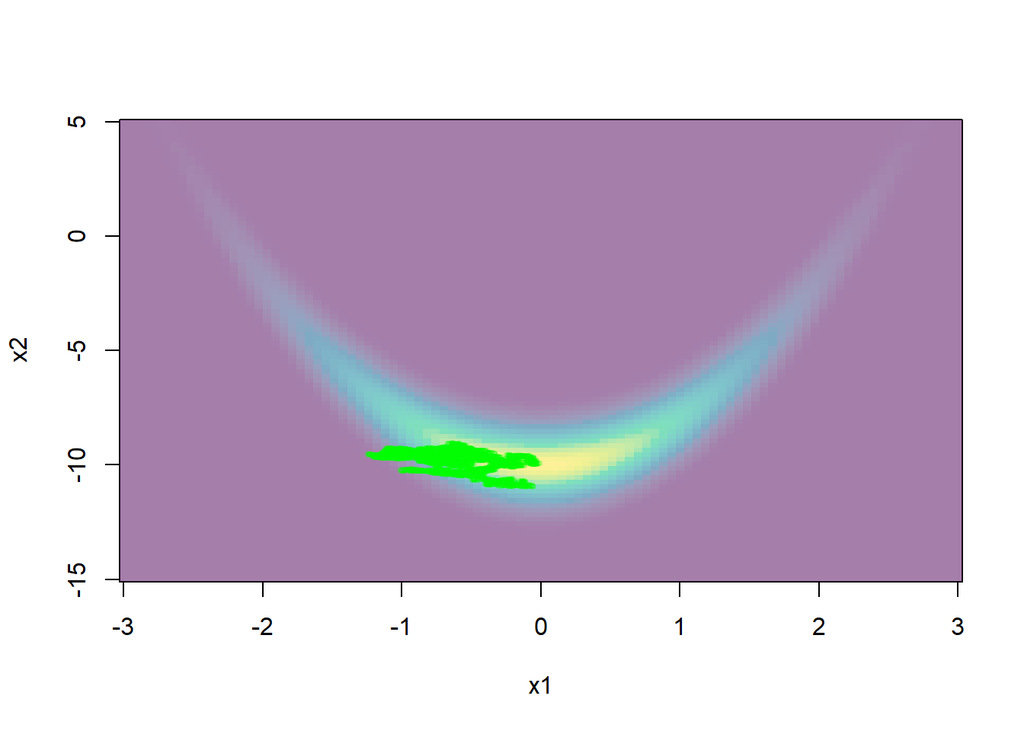

```r
par(mfrow=c(1,1))
image(x1, x2, f, col=hcl.colors(100, alpha=0.5),
      xlab=expression("x1"),
      ylab=expression("x2"))
points(mcmc.sim$x1, mcmc.sim$x2,  col=rgb(0,1,0,alpha=0.2), cex=0.5)
```

We can tell from the plot that the chain wander around a lot with eta=delta=0.01. Then we tried larger values.

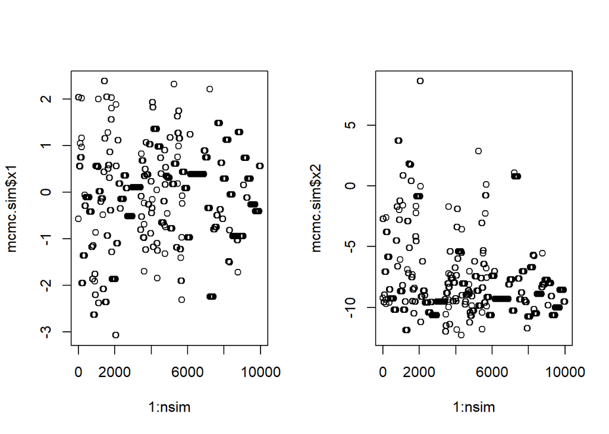

```r
# scenario 2
eta <- 10
delta <- 10
mcmc.sim <- mh.sim(nsim=nsim, eta=eta, delta=delta, burn=burn)
# plot
par(mfrow=c(1,2))
plot(1:nsim, mcmc.sim$x1)
plot(1:nsim, mcmc.sim$x2)
```

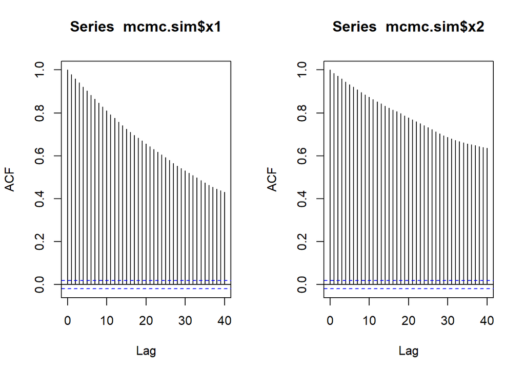

```r
acf(mcmc.sim$x1)
acf(mcmc.sim$x2)
```

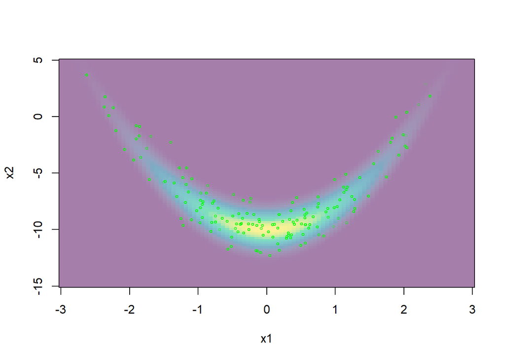

```r
par(mfrow=c(1,1))
image(x1, x2, f, col=hcl.colors(100, alpha=0.5),
      xlab=expression("x1"),
      ylab=expression("x2"))
points(mcmc.sim$x1, mcmc.sim$x2,  col=rgb(0,1,0,alpha=0.2), cex=0.5)
```

We can tell from the plot that some points of the chain are unchanged during the iteration with eta=delta=10. Then we tried smaller values.

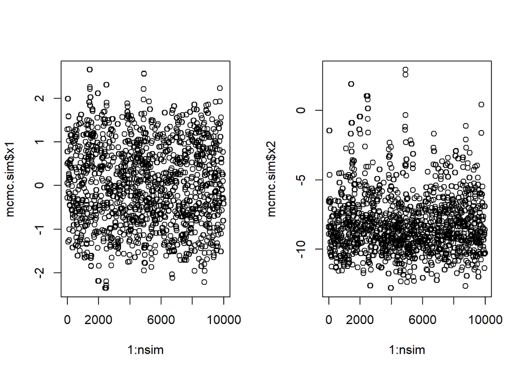

```r
# scenario 3
eta <- 3
delta <- 3
mcmc.sim <- mh.sim(nsim=nsim, eta=eta, delta=delta, burn=burn)
# plot
par(mfrow=c(1,2))
plot(1:nsim, mcmc.sim$x1)
plot(1:nsim, mcmc.sim$x2)
```

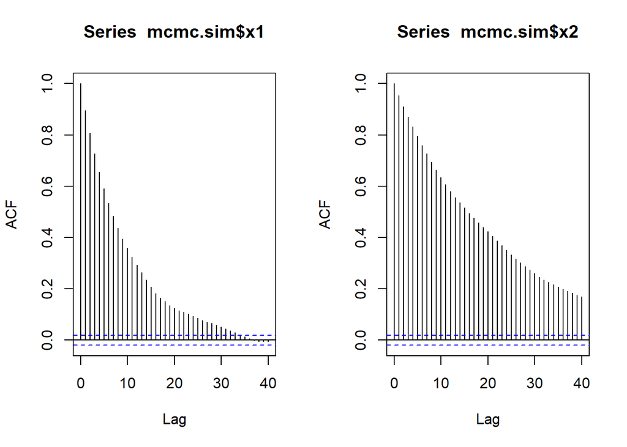

```r
acf(mcmc.sim$x1)
acf(mcmc.sim$x2)
```

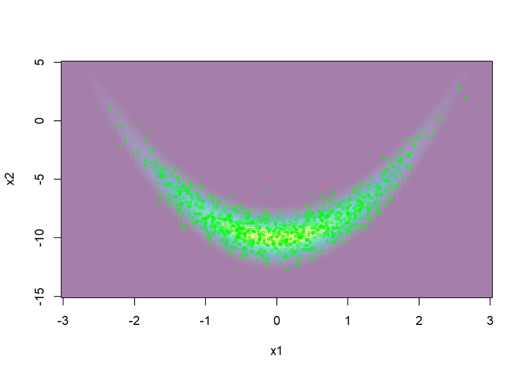

```r
par(mfrow=c(1,1))
image(x1, x2, f, col=hcl.colors(100, alpha=0.5),
      xlab=expression("x1"),
      ylab=expression("x2"))
points(mcmc.sim$x1, mcmc.sim$x2,  col=rgb(0,1,0,alpha=0.2), cex=0.5)
```

```r
mcmc.sim.d<-mcmc.sim
```

We can clearly tell from the plot that the chain’s convergence are improved with eta=delta=3. ACF plot also shows that autocorrelation approach to 0 faster.

### (e)

Construct a Markov Chain to sample from $\pi(x1; x2)$ updating iteratively $\pi(x1|x2)$ and $\pi(x2|x1)$ in a component-wise fashion, using the Metropolis Hastings algorithm. Compare convergence and mixing for different proposal jump sizes.

In this method, we tried to sample x1 and x2 iteratively by Metropolis Hastings algorithm.

```r
mh.it.sim <- function(nsim=1000, burn=0, eta=3, delta=5, seed=1996){
  set.seed(seed)
  x1 <- 0
  x2 <- -10
  nsim.total <- nsim*(1.0 + burn)
  burn.num <- nsim*burn
  x1.ch <- vector()
  x2.ch <- vector()

  for(i in 1:nsim.total){
    x1_temp <- rnorm(1,x1,eta)
    x2_temp <- rnorm(1,x2,delta)
    P0 <- .banana(x1, x2) %>% log
    # x1|x2
    P1 <- .banana(x1_temp, x2) %>% log
    ratio <- P1 - P0
    if(log(runif(1)) < ratio){
      x1 <- x1_temp
      P0 <- P1
    }
    # x2|x1
    P1 <- .banana(x1, x2_temp) %>% log
    ratio <- P1 - P0
    if(log(runif(1)) < ratio){
      x2 <- x2_temp
    }
    # burn in
    if(i > burn.num){
      i1 <- i - burn.num
      x1.ch[i1] = x1
      x2.ch[i1] = x2
    }
  }
  return(list(x1=x1.ch, x2=x2.ch))
}
```

simulation begin, using same parameters setting as last question.

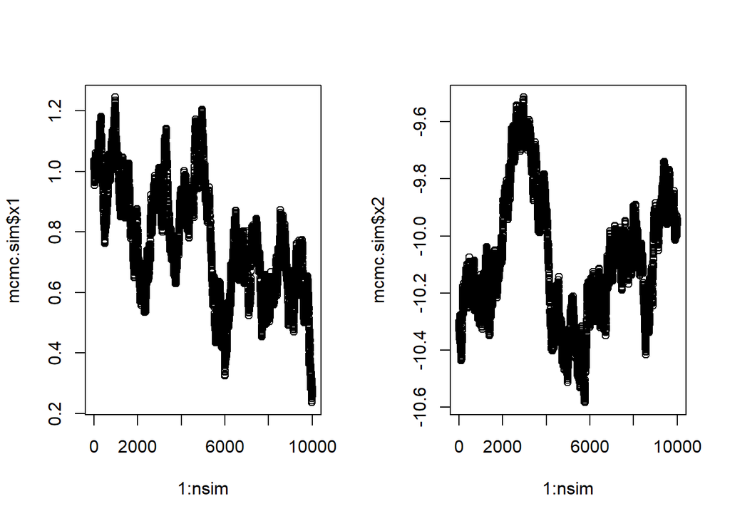

```r
burn=0.3
nsim=10000

# scenario 1
eta <- 0.01
delta <- 0.01
mcmc.sim <- mh.it.sim(nsim=nsim, eta=eta, delta=delta, burn=burn)
# plot
par(mfrow=c(1,2))
plot(1:nsim, mcmc.sim$x1)
plot(1:nsim, mcmc.sim$x2)
```

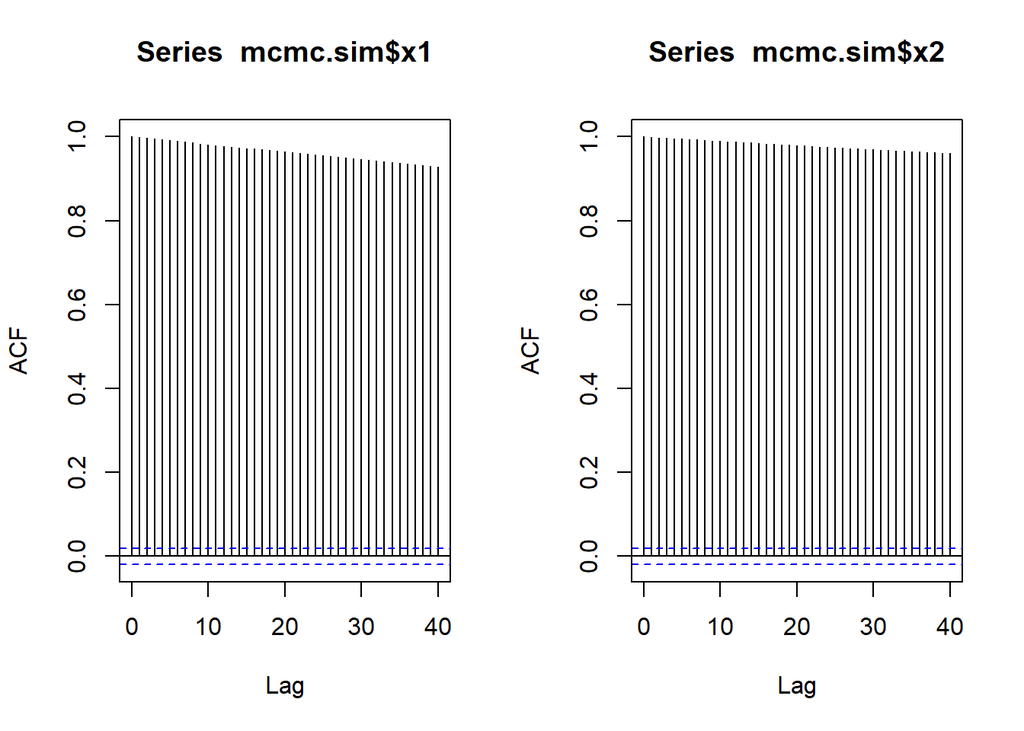

```r
acf(mcmc.sim$x1)
acf(mcmc.sim$x2)
```

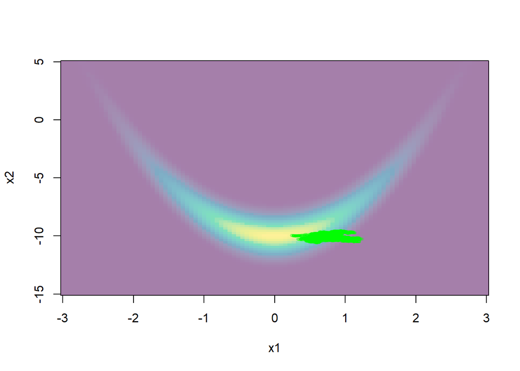

```r
par(mfrow=c(1,1))
image(x1, x2, f, col=hcl.colors(100, alpha=0.5),
      xlab=expression("x1"),
      ylab=expression("x2"))
points(mcmc.sim$x1, mcmc.sim$x2,  col=rgb(0,1,0,alpha=0.2), cex=0.5)
```

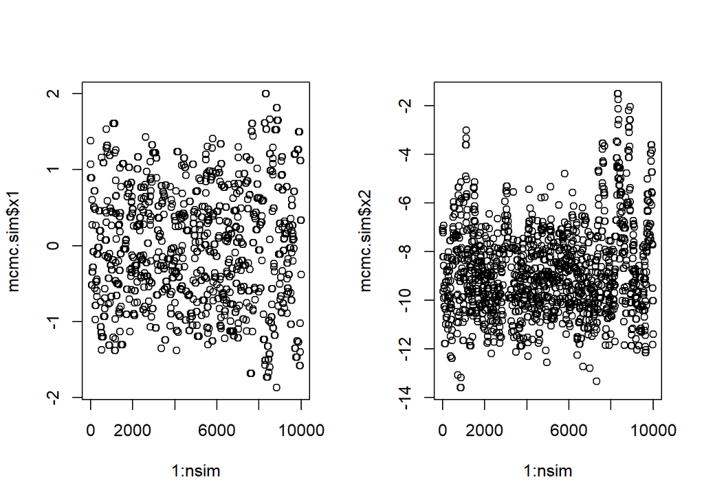

```r
# scenario 2
eta <- 10
delta <- 10
mcmc.sim <- mh.it.sim(nsim=nsim, eta=eta, delta=delta, burn=burn)
# plot
par(mfrow=c(1,2))
plot(1:nsim, mcmc.sim$x1)
plot(1:nsim, mcmc.sim$x2)
```

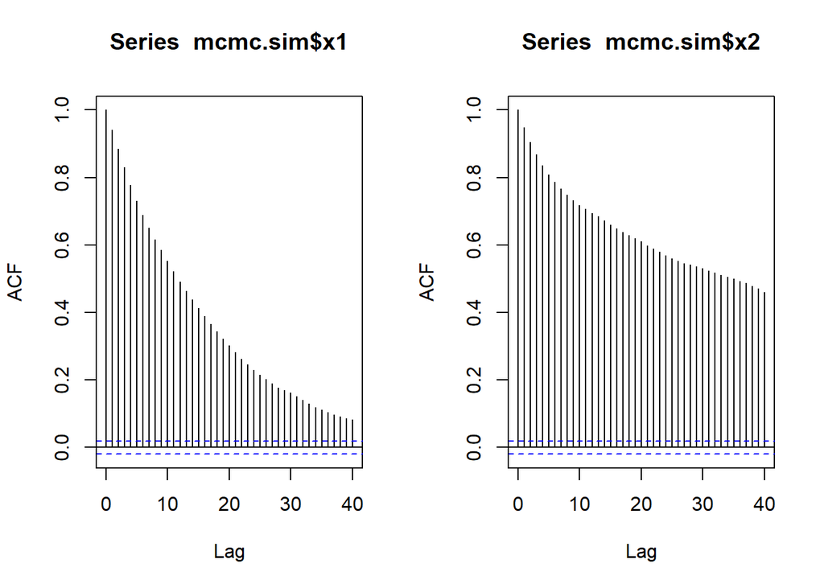

```r
acf(mcmc.sim$x1)
acf(mcmc.sim$x2)
```

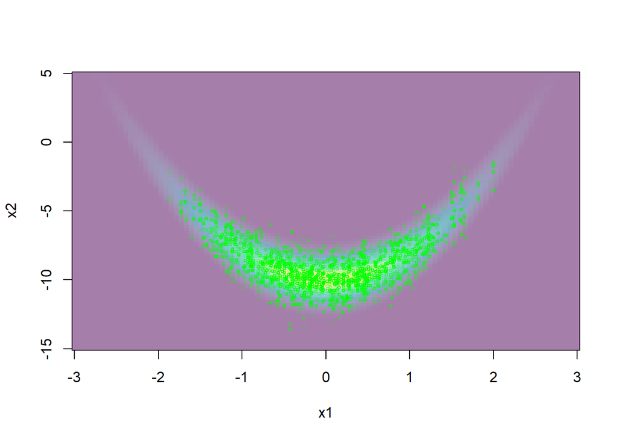

```r
par(mfrow=c(1,1))
image(x1, x2, f, col=hcl.colors(100, alpha=0.5),
      xlab=expression("x1"),
      ylab=expression("x2"))
points(mcmc.sim$x1, mcmc.sim$x2,  col=rgb(0,1,0,alpha=0.2), cex=0.5)
```

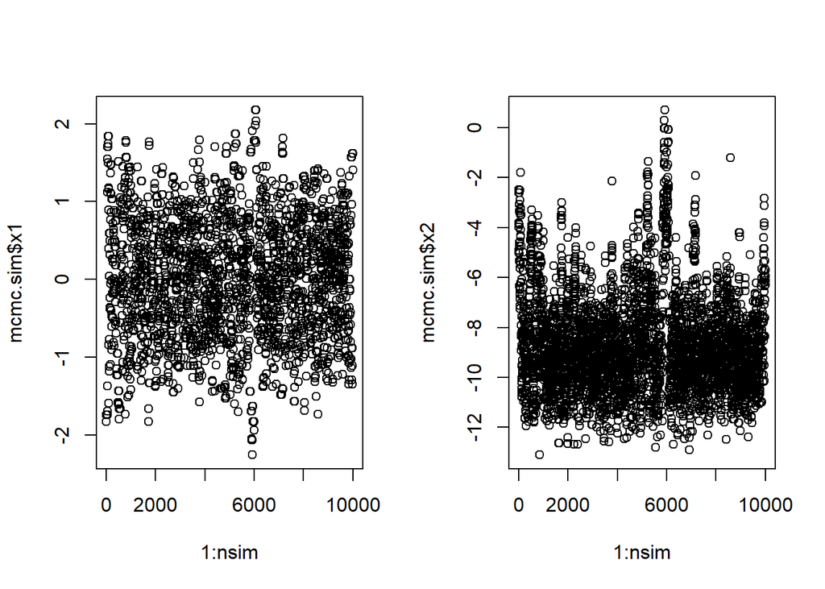

```r
burn=0.3
nsim=10000

# scenario 3
eta <- 3
delta <- 3
mcmc.sim <- mh.it.sim(nsim=nsim, eta=eta, delta=delta, burn=burn)
# plot
par(mfrow=c(1,2))
plot(1:nsim, mcmc.sim$x1)
plot(1:nsim, mcmc.sim$x2)
```

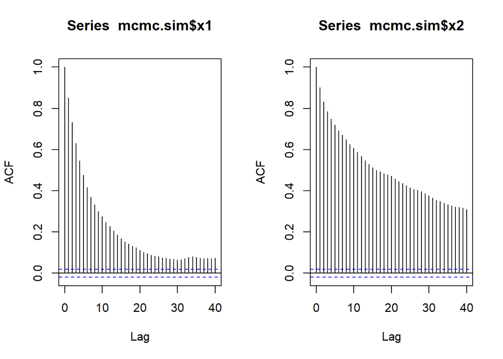

```r
acf(mcmc.sim$x1)
acf(mcmc.sim$x2)
```

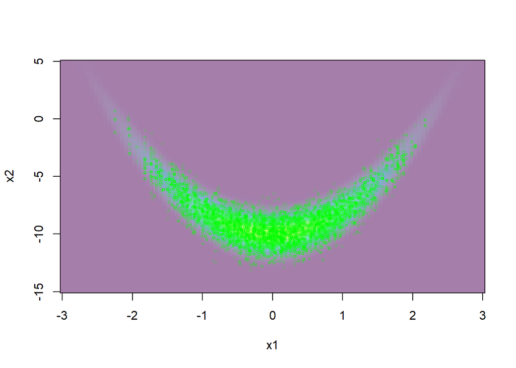

```r
par(mfrow=c(1,1))
image(x1, x2, f, col=hcl.colors(100, alpha=0.5),
      xlab=expression("x1"),
      ylab=expression("x2"))
points(mcmc.sim$x1, mcmc.sim$x2,  col=rgb(0,1,0,alpha=0.2), cex=0.5)
```

```r
mcmc.sim.e<-mcmc.sim
```

### (f)

Repeat (e) using component-wise Gibbs sampling.

From 1 we know that:

- $P(x_2|x_1) \sim N(2(x_1^2-5), 1)$

Then we can use component-wise Gibbs sampling:

```r
mh.gib.sim <- function(nsim=1000, burn=0, eta=3, seed=1996){
  set.seed(seed)
  x1 <- 0
  x2 <- -10
  nsim.total <- nsim*(1.0 + burn)
  burn.num <- nsim*burn
  x1.ch <- vector()
  x2.ch <- vector()

  for(i in 1:nsim.total){
    x1_temp <- rnorm(1,x1,eta)
    P0 <- .banana(x1, x2) %>% log
    # x1|x2
    P1 <- .banana(x1_temp, x2) %>% log
    ratio <- P1 - P0
    if(log(runif(1)) < ratio){
      x1 <- x1_temp
    }
    # x2|x1
    x2 <- rnorm(1, 2*(x1^2-5), 1)
    # burn in
    if(i > burn.num){
      i1 <- i - burn.num
      x1.ch[i1] = x1
      x2.ch[i1] = x2
    }
  }
  return(list(x1=x1.ch, x2=x2.ch))
}
```

simulation begin, using same parameters setting as last question.

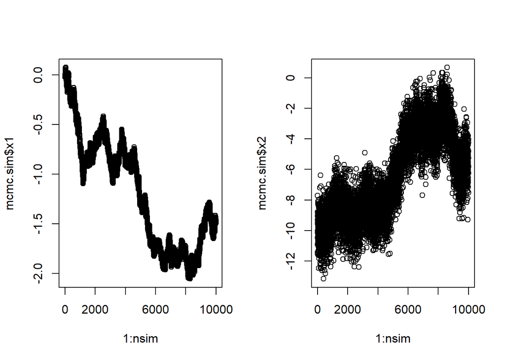

```r
burn=0.3
nsim=10000

# scenario 1
eta <- 0.01
mcmc.sim <- mh.gib.sim(nsim=nsim, eta=eta, burn=burn)
# plot
par(mfrow=c(1,2))
plot(1:nsim, mcmc.sim$x1)
plot(1:nsim, mcmc.sim$x2)
```

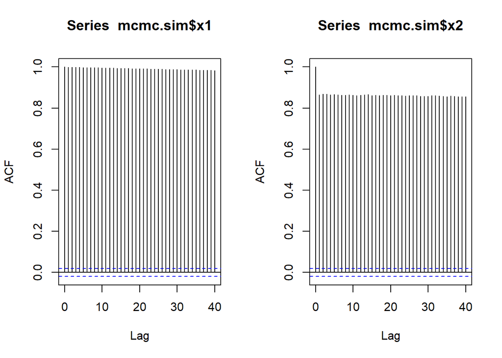

```r
acf(mcmc.sim$x1)
acf(mcmc.sim$x2)
```

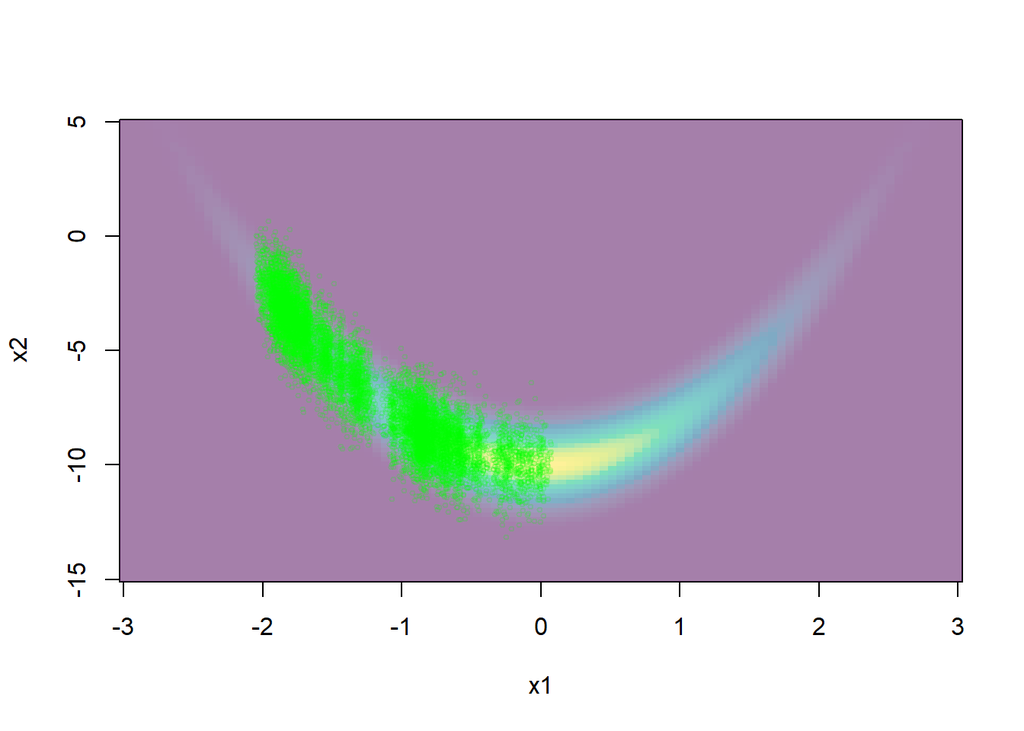

```r
par(mfrow=c(1,1))
image(x1, x2, f, col=hcl.colors(100, alpha=0.5),
      xlab=expression("x1"),
      ylab=expression("x2"))
points(mcmc.sim$x1, mcmc.sim$x2,  col=rgb(0,1,0,alpha=0.2), cex=0.5)
```

We can tell from the plot that the chain wander around a lot.

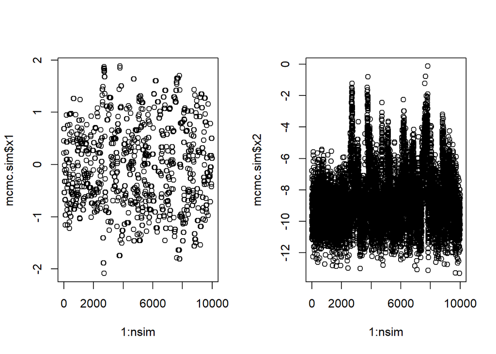

```r
# scenario 2
eta <- 10
mcmc.sim <- mh.gib.sim(nsim=nsim, eta=eta, burn=burn)
# plot
par(mfrow=c(1,2))
plot(1:nsim, mcmc.sim$x1)
plot(1:nsim, mcmc.sim$x2)
```

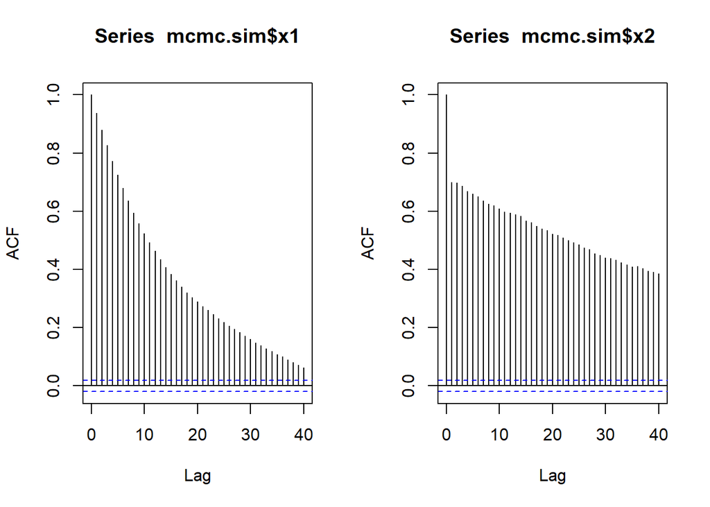

```r
acf(mcmc.sim$x1)
acf(mcmc.sim$x2)
```

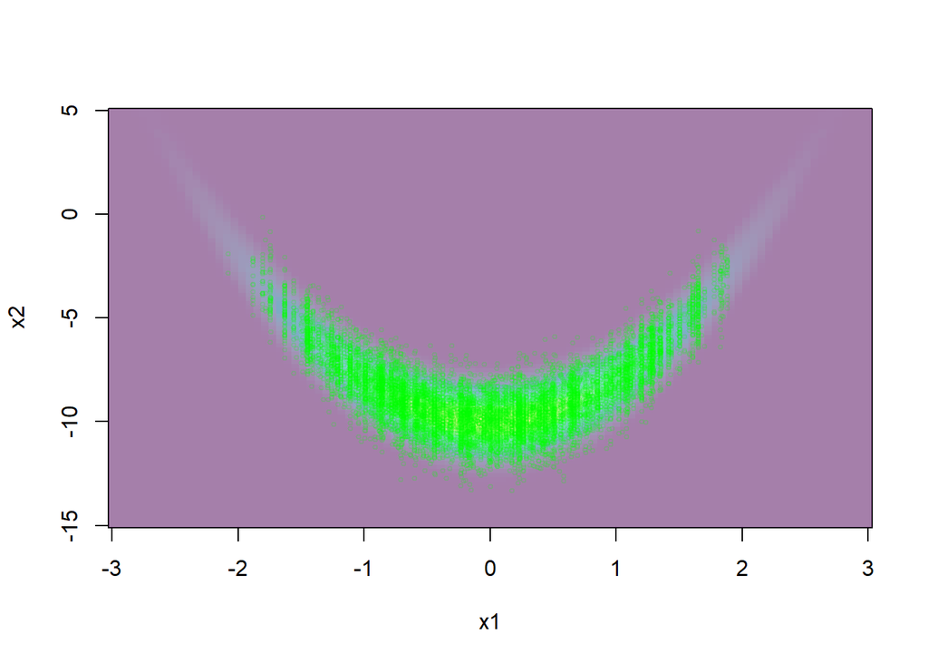

```r
par(mfrow=c(1,1))
image(x1, x2, f, col=hcl.colors(100, alpha=0.5),
      xlab=expression("x1"),
      ylab=expression("x2"))
points(mcmc.sim$x1, mcmc.sim$x2,  col=rgb(0,1,0,alpha=0.2), cex=0.5)
```

```r
mcmc.sim.f<-mcmc.sim
```

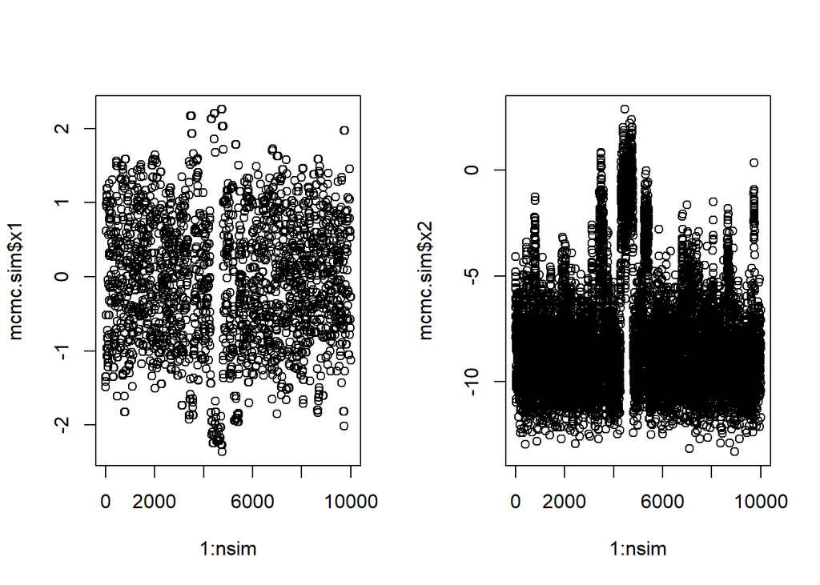

```r
# scenario 3
eta <- 3
mcmc.sim <- mh.gib.sim(nsim=nsim, eta=eta, burn=burn)
# plot
par(mfrow=c(1,2))
plot(1:nsim, mcmc.sim$x1)
plot(1:nsim, mcmc.sim$x2)
```

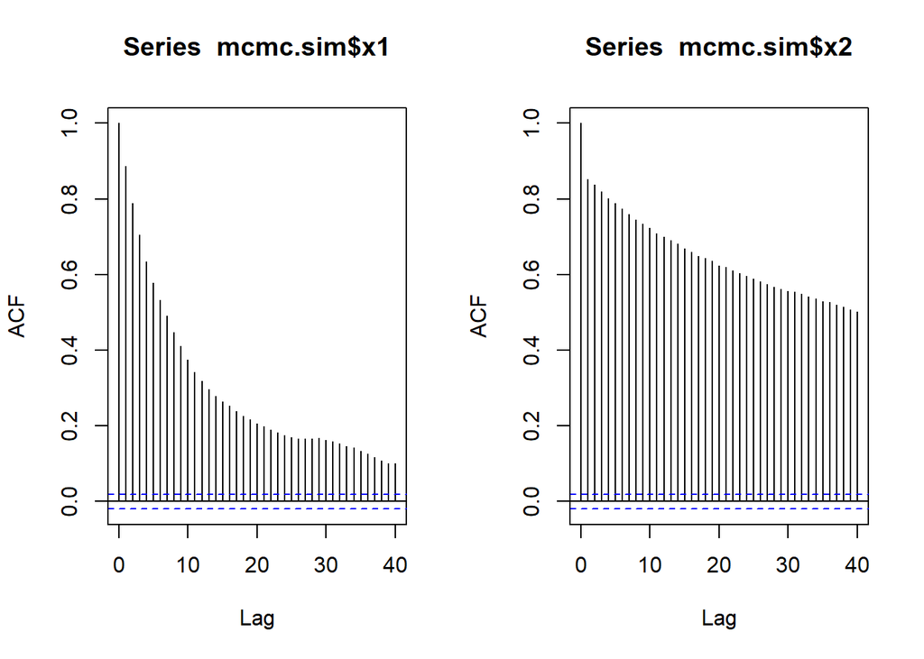

```r
acf(mcmc.sim$x1)
acf(mcmc.sim$x2)
```

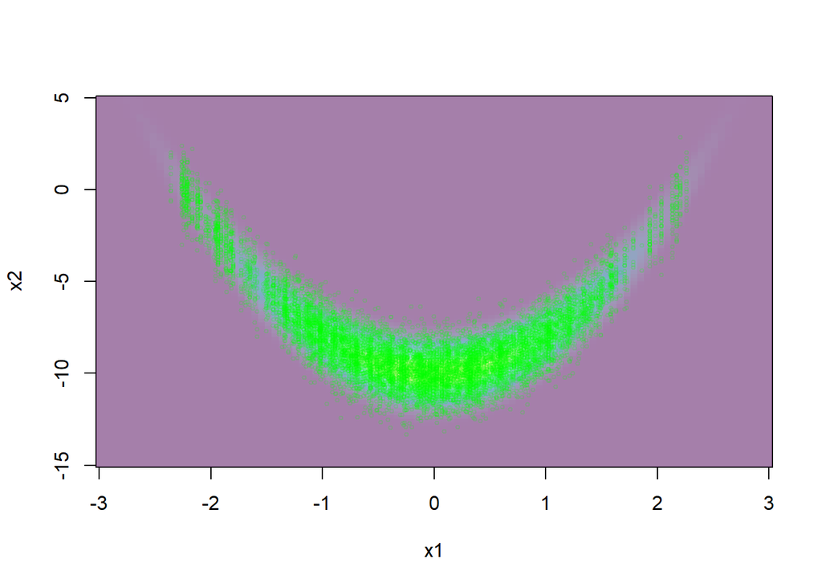

```r
par(mfrow=c(1,1))
image(x1, x2, f, col=hcl.colors(100, alpha=0.5),
      xlab=expression("x1"),
      ylab=expression("x2"))
points(mcmc.sim$x1, mcmc.sim$x2,  col=rgb(0,1,0,alpha=0.2), cex=0.5)
```